# R Supervised Learning Skills Demo

Kate Meldrum

NOTE: These analyses were done as part of a class at the University of Virginia. Though all code is mine, some problem descriptions are written by professor(s)

# Required R packages and Directories

```r
library(R6030)     # functions for DS 6030
library(ks)        # functions for KDE
library(tidyverse) # functions for data manipulation
library(fitdistrplus)
```

# Bootstrapping

## a. Create a set of functions to generate data

```r
f <- function(x) 1 + 2*x+5*sin(5*x)
gen_sample <- function(n){
  x <- runif(n, 0, 2)
  e <- rnorm(n, 0, 2.5)
  y <- f(x)+e
  return(data.frame(x,y,e))
}
```

## b. Simulate $n=100$ realizations from these distributions. Produce a scatterplot and draw the true regression line $f(x) = E[Y \mid X=x]$

```r
set.seed(211)
datab <- gen_sample(100)
```

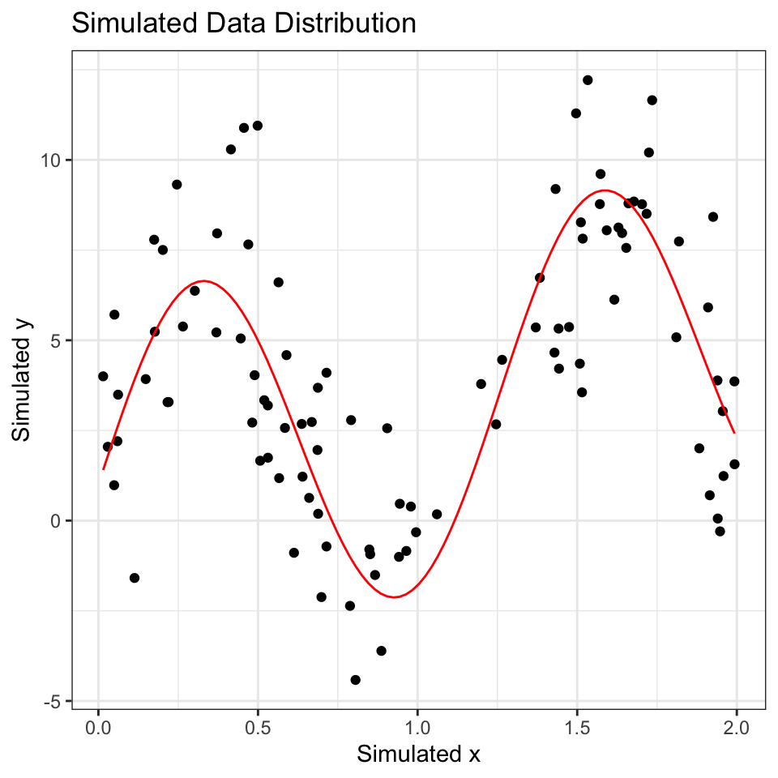

```r
plotb <- ggplot(data=datab, aes(x=x, y=y))+
  geom_point()+
  labs(x="Simulated x", y="Simulated y", title="Simulated Data Distribution")
plotb + stat_function(fun=f, color='red')
```

## c. Fit a 5th degree polynomial. Produce a scatterplot and draw the *estimated* regression curve.

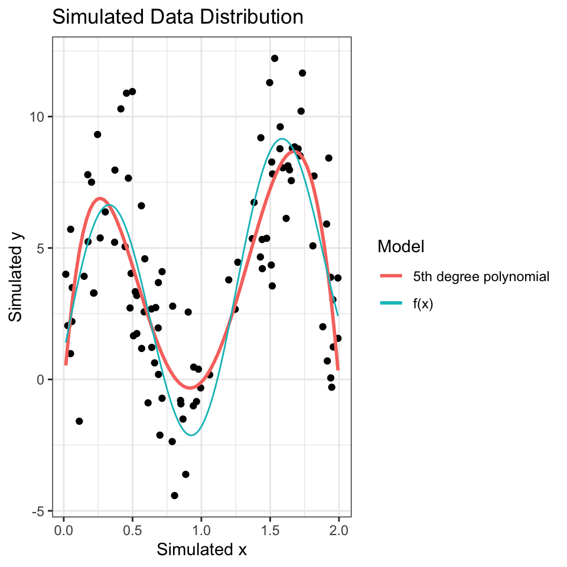

```r
ggplot(data=datab, aes(x,y)) +
  geom_point()+
  geom_smooth(method="lm", formula="y~poly(x,5)", se=FALSE, aes(color="5th degree polynomial")) +
  stat_function(fun=f, aes(color="f(x)"))+
  scale_color_discrete(name="Model")+
  labs(x="Simulated x", y="Simulated y", title="Simulated Data Distribution")
```

```r
bootstraps <- data.frame(param=c('1', 'x', 'x^2', 'x^3', 'x^4', 'x^5'))
eval_pts = data.frame(x=seq(0, 2, length=100)) #eval points = 100 points between 0 and 2
preds <- data.frame(eval_pts = seq(0, 2, length=100)) #create a dataframe to store predicted f(x) of each eval point
#loop 200 times to make 200 bootstraps
for(i in 1:200){
  rows = sample.int(100, replace=TRUE)
  data.boot = datab[rows,]
  m.boot = lm(y~poly(x, degree=5), data=data.boot)
  eqn.boot <- broom::tidy(m.boot) %>% select(term, estimate)
  bootstraps <- cbind(bootstraps, estimate=eqn.boot$estimate) #save bootstrap eqns
  pred = predict(m.boot, newdata = eval_pts)
  preds[,i] <- pred #save predictions
}
```

[output not shown]

```r
data_fit = as_tibble(preds) %>% # convert matrix to tibble
bind_cols(eval_pts) %>% # add the eval points
pivot_longer(-x, names_to="simulation", values_to="y")
```

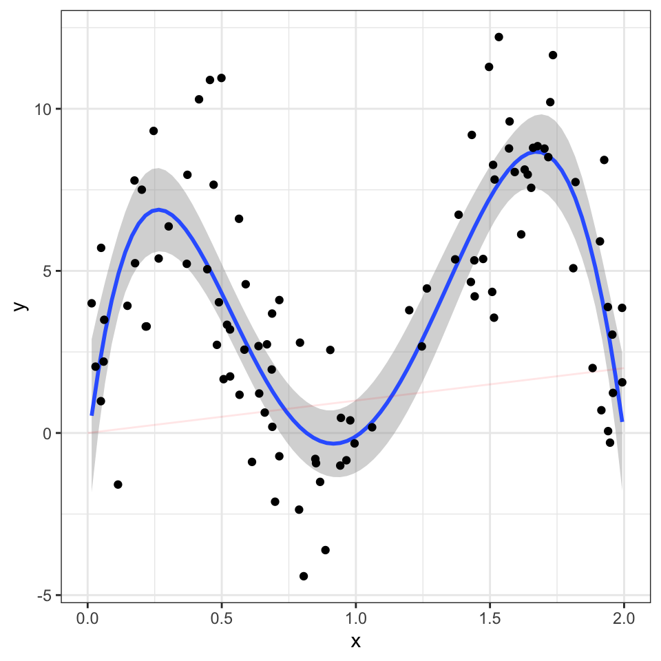

```r
#plot boostraps
ggplot(datab, aes(x,y)) +
geom_smooth(method='lm',
formula='y~poly(x,degree=5)')+
geom_line(data=data_fit, color="red", alpha=.10, aes(group=simulation)) +
geom_point()
```

```r
#make lists of lower and upper percentile values of bootstrap curve for each value in eval points
lq <- c()
uq <- c()
for(x in 1:100){
  lqi <- quantile(preds[x, -1], probs=c(0.025), na.rm=TRUE)
  lq <- append(lq, lqi)
  uqi <- quantile(preds[x, -1], probs=c(0.975), na.rm=TRUE)
  uq <- append(uq, uqi)}
```

```r
range <- data.frame(uq, lq)
```

```r
data_fit2 = as_tibble(range) %>% # convert matrix to tibble
  bind_cols(eval_pts) %>% # add the eval points
  pivot_longer(-x, names_to="simulation", values_to="y")
```

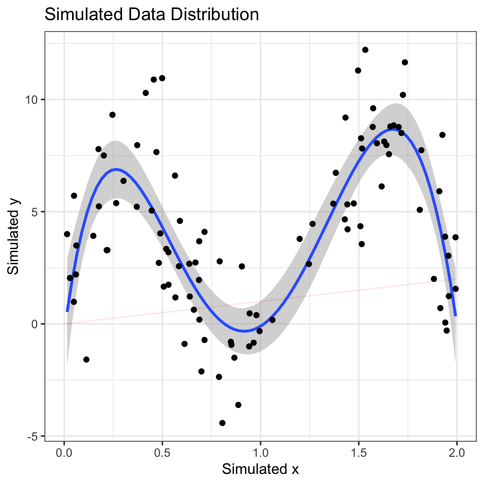

```r
#plot boostraps with the 2.5 percentile curve and the 97.5 percentile curve
ggplot(datab, aes(x,y)) +
  geom_smooth(method='lm', formula='y~poly(x,degree=5)')+
  geom_line(data=data_fit, color="red", alpha=.10, aes(group=simulation)) +
  geom_line(data=data_fit2, color="blue", aes(group=simulation))+
  labs(x="Simulated x", y="Simulated y", title="Simulated Data Distribution")+
  geom_point()
```

# Parametric and KDE Density Analysis

```r
setwd('/Users/meldrumapple/Desktop/SL/Homework 5')
data <- read.csv('geo_profile.csv')
data
```

| x |
| --- |
| 2.5818 |
| 2.1085 |
| 5.3542 |
| 3.8671 |
| 2.8514 |
| 2.7098 |
| 2.0195 |
| 1.2779 |
| 4.0717 |
| 1.3596 |

[output cut: 273 more lines]

Geographic profiling, a method developed in criminology, can be used to estimate the [home location (roost) of animals](https://www.sciencedirect.com/science/article/pii/S0022519305004157) based on a collection of sightings. The approach requires an estimate of the distribution the animal will travel from their roost to forage for food.

One probability model for the distance these bats will travel is:
$$\begin{align*}
f(x; \theta) = \frac{x}{\theta} \exp \left( - \frac{x^2}{2 \theta}
\right)
\end{align*}$$
where the parameter $\theta > 0$ controls how far they are willing to travel.

## a. Derive the MLE for $\theta$

$$L(\theta)=\prod_{i=1}^{n}\frac{x_i}{\theta}e^{\frac{-x_i^2}{2\theta}}=(\frac{1}{\theta})^n\prod_{i=1}^{n}{x_i}e^{\frac{-x_i^2}{2\theta}}$$

$$ln(L(\theta))=nln(\theta)+\sum_{i=1}^{n}ln(x_i)+\sum_{i=1}^{n}\frac{-x_i^2}{2\theta}$$

$$\frac{d}{d\theta}ln(L(\theta))=\frac{-n}{\theta}+\frac{1}{\theta^2}\sum_{i=1}^{n}\frac{x_i^2}{2}=0$$

$$\hat{\theta}=\sum_{i=1}^{n}\frac{x_i^2}{2n}$$

## b. What is the MLE of $\theta$ for the bat data?

```r
t_mle <- sum(((data$x^2)/(2*nrow(data))))
t_mle
```

```
#> [1] 4.524
```